# Running a DWBA simulation programmatically

Sven Gastauer

4th of May 2018

This vignette will provide a brief description of the DWBA model used within the ZooScat package, explain the needed input parameters and provide a few examples.

## Quick Start

For a quick start, a minimal example:

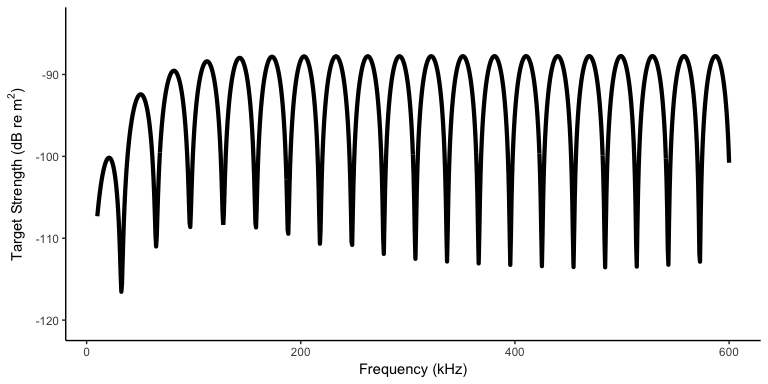

```r
fname <- paste0(system.file(package="ZooScat"),"/extdata/configs/config_0.dat") #Loacation of the parameters file
para = read_para(fname) #Read parameters file
#Create list with soundspeed info
misc <- list(cw=1500)
#Run DWBA based on config file
res <- bscat(para=para, misc=misc) #Target strength vs Frequency
res$rplot #Show the result plot
```

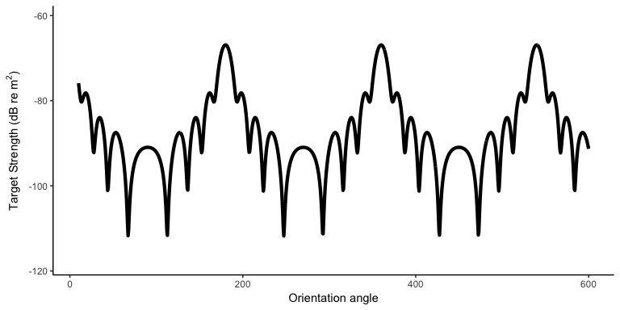

```r
#Target strength vs angular position
para$simu$var_indx <- 2 #Set output variable to Angular position
#Run DWBA based on config file
res <- bscat(para=para, misc=misc)
res$rplot #Show the result plot
```

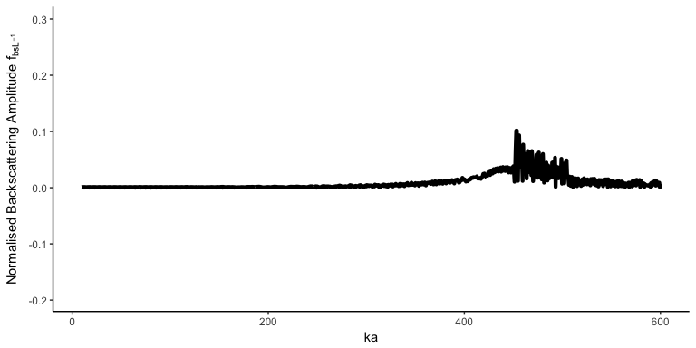

```r
#Backscattering amplitude vs ka (Wavenumber x width)
para$simu$out_indx <- 1 #Set output to Backscattering amplitude
para$simu$var_indx <- 3 #Set output variable to ka
#Run DWBA based on config file
res <- bscat(para=para, misc=misc)
res$rplot #Show the result plot
```

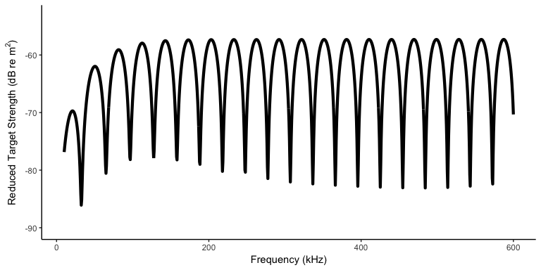

```r
#Reduced Target Strength vs Frequency (Wavenumber x width)
para$simu$out_indx <- 4 #Set output to Reduced Target Strength
para$simu$var_indx <- 1 #Set output variable to Frequency
#Run DWBA based on config file
res <- bscat(para=para, misc=misc)
res$rplot #Show the result plot
```

## The DWBA model - a brief explanation

- $f_{bs}$ is the scattering amplitude,
- $k$ is the wavenumber defined as $\frac{2\pi}{\lambda}$ where $\lambda$ is the acoustic wavelength [m].
- $\lambda = \frac{f}{c}$ with freqency $f$ in [Hz] and $c$ the soundspeed in the surrounding fluid [m/s]),
- the subscript $s$ refers to the surrounding fluid, the subscribt $b$ refers to the scattering body,
- $\vec{r_{pos}}$ is the position vector along the body axis,
- $v$ in the general model is the integration vloume of the body with the position vector $\vec{r_{pos}}$
- $\gamma_k$ and $\gamma_{rho}$ are related to the body material properties $g$ - the density contrast and $h$ the soundspeed contrast. Both contrast are the ratio of the density ($\frac{\rho_b}{\rho_s}$) or soundspeed ($\frac{c_b}{c_s}$) inside the body and the surrounding fluid.
  - $\gamma_k = \frac{(1 - gh2)}{gh2}$ is the compressibility
  - $\gamma_{\rho} = \frac{(g - 1)}{g}$ is related to the density contrast
- $J_1$ is a Bessel function of the first kind and first order
- $\beta_{tilt}$ is the angle between the incident wave and the target axis.

The equation part inside the shape integral for the DWBA can be split up into three parts:

- The material properties $\gamma_k - \gamma_{\rho}$
- The phase $e^{2i\vec{k_b}\vec{r_v}}dv$
- The shape (rest)

## Loading parameters into ZooScat

Before the DWBA model can be run several parameters have to be set.  
Some example configuration files containing all parameters can be found in: /Library/Frameworks/R.framework/Versions/3.4/Resources/library/ZooScat/extdata/configs Parameters (config files) can be loaded into ZooScat:

```r
# filenmae of an example configuration
fname <- paste0(system.file(package="ZooScat"),"/extdata/configs/config_0.dat")
#Read the parameter file
para <- read_para(fname)
```

the read_para function will load the model parameters as a list of 5:

- …$fname - Can be ignored in the scripting version but can be used within the DWBAapp()
- …$shape - Contains all the shape parameters
- …$orient - Contains the orientation parameters
- …$phy - Contains the material properties
- …$simu - Contains the simulation settings

## The input parameters

Based on the previously discussed parts of the equation and the structure of the parameters file, the DWBA takes four different categories of input parameters (shape, orientation, material properties and modelling parameters).

A brief description, the input format, the influence of the parameter and its name within the parameter list are outlined below:

### Shape parameters

| Variable | Unit | Description | Influence | Parameters name |
| --- | --- | --- | --- | --- |
| Length(L) | mm | The total target body length | Length of the target | …shape$L |
| ρc/L | ratio | Ratio of the radius of curvature (ρc) and L | Curvature of the bent cylinder, if no shape profile is loaded ( ∞ for straight cylinder) | …shape$rho_L |
| L/a | ratio | L/a with a the radius of the mid-point of the cylinder is the ratio of L to a | Contains information about the width of the target. | …shape$L_a |
| Taper order | float | The taper order (n) controls the tapering. | For a straight cylinder (ρc/L -> infinity), n=2 results in a prolate spheroid if L>2a, or in an oblate spheroid for L<2a | …shape$order |
| Length average | boolean | The average model over a range of lengths will be produced | 1 = perform average; 0 = No average |  |
| std(L)/L | mm | The ratio of the standard deviation of length (std(L)) to the mean length (L) | Defines the variability of the target lengths, used to compute the input models for the averaged model output | …shape$Lstd |
| Length increment | mm | This value has to be chosen with care, as it has to be possible to calculate the provided std(L)/mean(L) around the provided mean L with the given increment. | Defines the length increment of the target lengths, used to compute the input models for the averaged model output | …shape$dL |
| Shape profile | filepath | Path to a profile file containing 3 or 5 columns. (X, Z, R coordinates and optional Xupper Xlower). The profile file must contain at least 3 columns, containing the center coordinates (X, Z, R) of eac… | Defines the shape of the target, if no profile is selected a uniformly bent cylinder will be computed | …shape$prof_name |
| Taper smooth | float | Filter length to smooth the radius (R) | 1 = no smoothing, otherwise smoothes the tapering (reduces complexity) | …shape$taper_sm |
| Axis smooth | float | Filter length to smooth the body axis (X, Z) | 1 = no smoothing, otherwise smoothens the axis (flatter) | …shape$axis_sm |

### Orientation parameters:

| Variable | Unit | Description | Influence | Parameters name |
| --- | --- | --- | --- | --- |
| Mean Theta (θ) | ° | Mean orientation angle |  | …orient$angm |
| Orientation Average | Boolean | Defines if an orientation average should be considered |  | …orient$ave_flag |
| Theta Distribution (dθ) | distribution (Uniform or Gaussian) | PDF of theta | 1) Uniform; 2) Gaussian | …orient$PDF |
| Min. Theta (θmin) | ° | Minimum theta for a uniform PDF |  | …orient$ang0 |
| Max. Theta (θmax) | ° | Maximum theta for a uniform PDF |  | …orient$ang1 |
| Std.(θ) | ° | Standard deviation of theta for a Gaussian PDF |  | …orient$PDF_para |
| Increment θ | ° | Incremental step of theta for a Gaussian PDF |  | …orient$dang |

### Material properties parameters

| Variable | Unit | Description | Influence | Parameters name |
| --- | --- | --- | --- | --- |
| Density contrast (g) | ratio | the ratio of the density of the animal to the density of the surrounding fluid | Influences acoustic impedance, should be within [0.95, 1.05] | …phy$g0 |
| Soundspeed contrast (h) | ratio | the ratio of the sound speed in the animal to the sound speed in the surrounding fluid | Influences acoustic impedance, should be within [0.95, 1.05] | …phy$h0 |
| Ambient Soundspeed (c) | m/s | Soundspeed in surrounding fluid |  | …misc$cw |
| N body segment | Integer | Defines the number of segments with different gi and hi along the body axis (>1 if an inhomogenous body should be computed). |  | …phy$seg_no |
| std(g) | std of ratio | Standard deviation of the density (g), if an inhomogenous body should be computed |  | …phy$g_std |
| std(h) | std of ratio | Standard deviation of the sound speed contrast (h), if an inhomogenous body should be computed |  | …phy$h_std |
| Correlation Length | % of L | Controls the variability of g and h along the body axis (only xonsidered if the number of segments is >8) |  | …phy$corrL |

### Simulation parameters

[output not shown]

## Changing the configuration parameters

The configuration files can be changed either within a text editor or the different parameters can be directly changed within R:

```r
#Changing the length of the scattering target
message(paste("Old length:", para$shape$L))
```

```
#> Old length: 30
```

```r
para$shape$L <- 40
message(paste("New length:", para$shape$L))
```

```
#> New length: 40
```

```r
#Changing the mean orientation of the scattering target
message(paste("Old orientation angle:", para$orient$angm))
```

```
#> Old orientation angle: -60
```

```r
para$orient$angm <- 30
message(paste("New orientation angle:", para$orient$angm))
```

```
#> New orientation angle: 30
```

```r
#Changing the density contrast
message(paste("Old density contrast:", para$phy$g0))
```

```
#> Old density contrast: 1.0357
```

```r
para$phy$g0 <- 1.031
message(paste("New density contrast:", para$phy$g0))
```

```
#> New density contrast: 1.031
```

```r
#Changing the output start value
message(paste("Old output start value:", para$simu$var0))
```

```
#> Old output start value: 10
```

```r
para$simu$var0 <- 38
message(paste("New output start value:", para$simu$var0))
```

```
#> New output start value: 38
```

```r
#Changing the output end value
message(paste("Old output end value:", para$simu$var1))
```

```
#> Old output end value: 600
```

```r
para$simu$var0 <- 200
message(paste("New output end value:", para$simu$var1))
```

```
#> New output end value: 600
```

Alternatively, the settings can be loaded into the DWBAapp(), changed and saved from within the shiny app.

## Using shape profiles or uniformely bent cylinder

Shape profiles can be used to define arbitrary shapes of the scattering target.

The buildpos(para = list of parameters, disp_prof = 1 (include or exclude ggplot element) function can be used to generate shapes. Buildpos builds the coordinate vectors related to the shape positions along the z-axis. The buildpos function takes the following parameters from the parameters list:

- shape$L - Length of the shape
- shape$ni - Number of integration points
- shape$order - Tapering order (ignored if prof_name is given)
- shape$rho_L rho - L/radius of curvature (ignored if prof_name is given)
- shape$prof_name - Custom shape, -1 for regular shape, filename for custom shape
- shape$axis_sm - smoothing along the x axis (uses smooth function)
- shape$taper_sm - smooths the tapering (simplifies the shape)

The function outputs a list of 8:

- r_pos - Position vector
- th_tilt - Angular information
- dr - distance vector
- gamma_t - atan2(z, x)
- taper - tapering
- x - x coordinates (normalised by rho and L for unifomly bent cylinder, normalised for the number of integration points and L if a shape profile is loaded)
- z - z coordinates (normalised by rho and L for unifomly bent cylinder, normalised for the number of integration points and L if a shape profile is loaded)
- plot - a ggplot of the generated shape, included if disp_prof is set to 1

```r
cyl <- buildpos(para)
message(paste("Length:",para$shape$L))
```

```
#> Length: 40
```

```r
message(paste("L/a:",para$shape$L_a))
```

```
#> L/a: 16
```

```r
message(paste("Tapering order:",para$shape$order))
```

```
#> Tapering order: 10
```

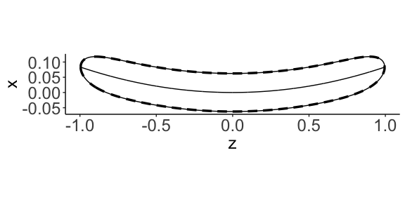

```r
cyl$plot
```

```r
para$shape$order <- 200
para$shape$L_a <- 3
cyl <- buildpos(para)
message(paste("Length:",para$shape$L))
```

```
#> Length: 40
```

```r
message(paste("L/a:",para$shape$L_a))
```

```
#> L/a: 3
```

```r
message(paste("Tapering order:",para$shape$order))
```

```
#> Tapering order: 200
```

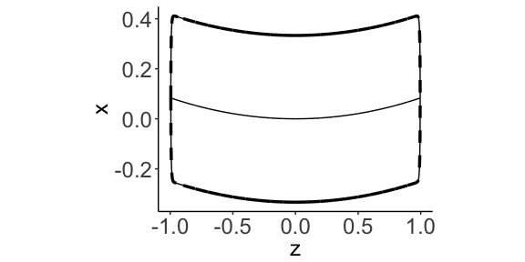

```r
cyl$plot
```

```r
para$shape$order <- 2
para$shape$L_a <- 2
para$shape$rhoL <- 200
cyl <- buildpos(para)
message(paste("Length:",para$shape$L))
```

```
#> Length: 40
```

```r
message(paste("L/a:",para$shape$L_a))
```

```
#> L/a: 2
```

```r
message(paste("Tapering order:",para$shape$order))
```

```
#> Tapering order: 2
```

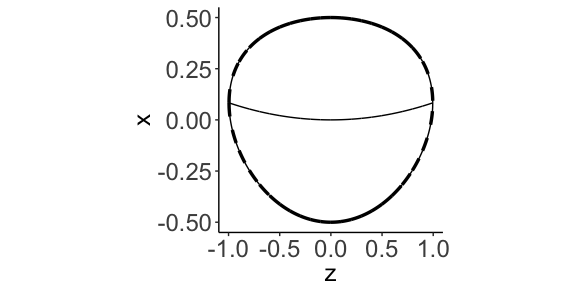

```r
cyl$plot
```

Input shape profiles must contain at least three columns with the center coordinates of each circular segment (X, Z) and radius of the circular segment (R). Two additional optional columns can be added to a shape file, the upper (Xupper -> X+R) and lower (Xlower -> X-R).  
Some example shape profiles can be found in /Library/Frameworks/R.framework/Versions/3.4/Resources/library/ZooScat/extdata/profiles

Shape profiles can be loaded and the altered:

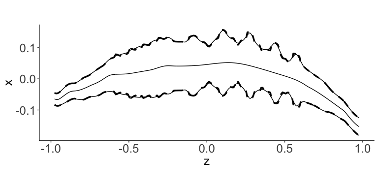

```r
# filenmae of an example configuration
fname <- paste0(system.file(package="ZooScat"),"/extdata/configs/config_0.dat")
#Read the parameter file
para <- read_para(fname)
#set the profile filename
profname <- paste0(system.file(package="ZooScat"),"/extdata/profiles/euphaus1.dat") #krill example
para$shape$prof_name <- profname
krill_shape1 <- buildpos(para)
krill_shape1$plot
```

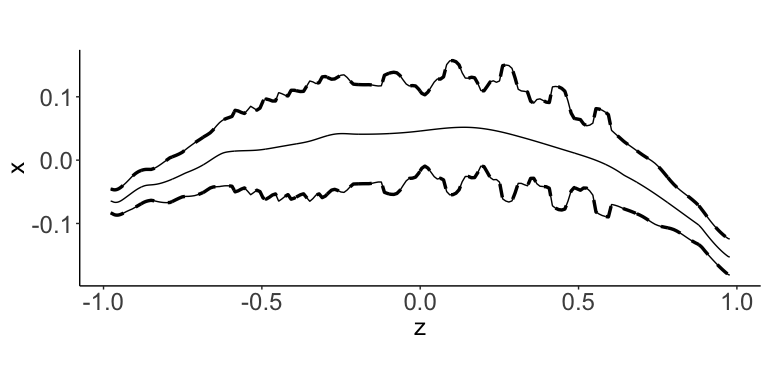

```r
#change the taper smoothing to no smoothing
para$shape$taper_sm <- 1
krill_shape1 <- buildpos(para)
krill_shape1$plot
```

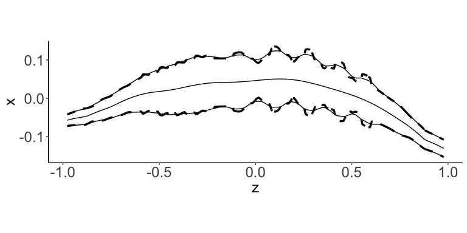

```r
#change the axis smoothing, taper smoothing and L/a
para$shape$L_a <- 20
para$shape$taper_sm <- 100
para$shape$axis_sm <- 200
krill_shape1 <- buildpos(para, disp_prof=1)
krill_shape1$plot
```

## Changing the material properties and soundspeed

Soundspeed and density contrast (h & g) are important variables in the model. It has been suggested that the effects of varying g and h can be of the same order of magnitude as the orientation (Stanton et al. 1993).  
The DWBA model has been reported to perform well for g & h values within 1 +/- 5% (0.95 - 1.05), i.e. weak scatterers.  
g & h can be either obtained experimentally or taken from literature values. The list below in a non-exhaustive list of g & h values found in literature. Large parts of the table are copied from Lavery et al. (2007) and Lawson et al. (2004).

Some taxa are represented more than once, where multiple literature recodrings have been found. It is recommended to throughly study the cited and other literature before using any of the presented values.

It should also be noted that L/a values might be fluctuating largely due to:

- geographical location (Køgeler et al. 1987; Lawson et al. 2004)
- life history traits of the taxon or seasonality (Lawson et al. 2004; Køgeler et al. 1987)

g and h in some species have been reported to fluctuate with:

- temperature (Chu and Wiebe 2005)
- size classes (Chu and Wiebe 2005; Lawson et al. 2004; Køgeler et al. 1987)
- depth (Chu and Wiebe 2005)
- seasonality (for example due to changes in lipid content) (Køgeler et al. 1987)
- state of the analysed individuals (preseverd or alive) (Køgeler et al. 1987).

| Taxon | Length-to-girth ratio $\frac{L}{a}$ | Orientation | Density Contrast g | Sound Speed Contrast h | Scattering model |
| --- | --- | --- | --- | --- | --- |
| Euphausiids and Decapod Shrimp | 10.5 | N(20,20) (Benfield, Davis, and Gallager 2000), average ~0 (Lawson et al. 2006) | $$\frac{5.485*L}{10^4}+1.002; L>25$$ $$1.016; L<25$$ (Lawson et al. 2004) | $$\frac{5.94*2L}{10^ 4}; L>25$$ $$1.019; L<25$$ (Lawson et al. 2004) | DWBA uniformly-bent cylinder |
| Larval Crustacean | 2.55 (Lawson et al. 2004) | N(0.30) (Lawson et al. 2004) | 1.058 (Lawson et al. 2004) | 1.058 (Lawson et al. 2004) | DWBA uniformly-bent cylinder |
| Amphipods | 3.00 (Lawson et al. 2004) | N(0,30) (Lawson et al. 2004) | 1.058 (Lawson et al. 2004) | 1.058 (Lawson et al. 2004) | DWBA uniformly-bent cylinder |
| Ostracods | 2.55 | N(0,30) | 1.03 (pers. comm. Dezhang Chu in Lavery et al. 2007) | 1.03 (pers. comm. Dezhang Chu in Lavery et al. 2007) | DWBA uniformly-bent cylinder |
| Chaetognaths and Polychaetes | 17.15 | N(0,30) | 1.03 (pers. comm. Dezhang Chu in Lavery et al. 2007) | 1.03 (pers. comm. Dezhang Chu in Lavery et al. 2007) | DWBA uniformly-bent cylinder |
| Gymnosome Pteropods (Clione) | 1.83 | N(0,30) | 1.03 (pers. comm. Dezhang Chu in Lavery et al. 2007) | 1.03 (pers. comm. Dezhang Chu in Lavery et al. 2007) | DWBA uniformly-bent cylinder |
| Salps | 4 | N(0,30) | 1.004 (Stanton et al. 1994) | 1.004 (Stanton et al. 1994) | DWBA uniformly-bent cylinder |
| Copepods | 2.55 | N(90,30) | 1.02 (pers. comm. Dezhang Chu in Lavery et al. 2007) | 1.058 (Chu, Wiebe, and Copley 2000) | DWBA prolate spheroid |
| Medusae | NA | NA | 1.02 (inferred from Monger et al. 1998 as reported in Lavery et al. (2007)) | 1.02 (inferred from Monger et al. 1998 as reported in Lavery et al. (2007)) | DWBA two prolate spheroid surfaces |
| Eggs | NA | NA | 0.979 (Chu et al. 2003) | 1.017 (Stanton 1989) | High-pass fluid sphere |
| Calanus finmarchicus | NA | NA | 1.025 - 1.029 g/cm<sup>3</sup> depending on season (Køgeler et al. 1987) | 1.027 (mixture C. finmarchicus and C. hyperboreus) (Køgeler et al. 1987) | NA |
| Calanus hyperboreus | NA | NA | 1.022 - 1.036 g/cm<sup>3</sup> depending on season (Køgeler et al. 1987) | 1.027 (mixture C. finmarchicus and C. hyperboreus) (Køgeler et al. 1987) | NA |
| Acartia clausi | NA | NA | 1.04 g/cm<sup>3</sup> (Greenlaw 1979) | NA | NA |
| Calanus marshallae | NA | NA | 1.04 g/cm<sup>3</sup> (Greenlaw 1979) | 1.007 (Køgeler et al. 1987) | NA |
| Meganyctiphanes norvegica | NA | NA | 1.057 g/cm<sup>3</sup> (Kils 1981) | 1.030 (Køgeler et al. 1987) | NA |
| Thysanoessa | NA | NA | 1.052 - 1.074 g/cm<sup>3</sup> depending on season and species (Køgeler et al. 1987) | 1.026 (Køgeler et al. 1987) | NA |
| Calanus | NA | NA | 1.022 - 1.036 g/cm<sup>3</sup> depending on season and species (Køgeler et al. 1987) | 1.027 (Køgeler et al. 1987); 0.949 & 1.013 - Depth dependent (Chu and Wiebe 2005) | NA |
| General | NA | NA | 0.9402 - 1.051 (Chu and Wiebe 2005) | 0.949 - 1.096 (Chu and Wiebe 2005) | NA |
| Euphausia superba | NA | NA | 1.0241 (Chu and Wiebe 2005), 1.0357 (Foote 1990) | 1.031 (Chu and Wiebe 2005), 1.0279 (Foote 1990) | NA |
| Euphausia crystallorophias | NA | NA | 1.009 & 1.000 depth dependent (Chu and Wiebe 2005) | 1.025 & 1.029 depth dependent (Chu and Wiebe 2005) | NA |
| Neocalanus cristatus | NA | NA | 0.997 - 1.009 (Matsukura et al. 2009) | 1.013 - 1.025 (Matsukura et al. 2009) | DWBA Deformed Cylinder |
| Neocalanus plumchrus | NA | NA | 0.995 - 1.009 (Matsukura et al. 2009) | 1.006 - 1.021 (Matsukura et al. 2009) | DWBA Deformed Cylinder |
| Ammodytes personatus (juvenile) | NA | NA | 1.021 (Yasuma et al. 2009) | 1.02 (Yasuma et al. 2009) | NA |
| Ammodytes personatus (adult) | NA | NA | 1.032 (Yasuma et al. 2009) | 1.02 (Yasuma et al. 2009) | NA |
| Salpa thompsoni | 10 | Uniform [0, π] | 1 - 1.0039 (Wiebe et al. 2009) | 1.006 - 1.0201 (Wiebe et al. 2009) | DWBA |

## References

Benfield, Mark C., Cabell S. Davis, and Scott M. Gallager. 2000. “Estimating the in-Situ Orientation of Calanus Finmarchicus on Georges Bank Using the Video Plankton Recorder.” *Plankton Biol. Ecol* 47 (1): 69–72.

Chu, Dezhang, and Peter H. Wiebe. 2005. “Measurements of Sound-Speed and Density Contrasts of Zooplankton in Antarctic Waters.” *ICES Journal of Marine Science* 62 (4): 818–31.

Chu, Dezhang, Peter H. Wiebe, Nancy J. Copley, Gareth L. Lawson, and Velmurugu Puvanendran. 2003. “Material Properties of North Atlantic Cod Eggs and Early-Stage Larvae and Their Influence on Acoustic Scattering.” *ICES Journal of Marine Science* 60 (3): 508–15.

Chu, Dezhang, Peter Wiebe, and Nancy Copley. 2000. “Inference of Material Properties of Zooplankton from Acoustic and Resistivity Measurements.” *ICES Journal of Marine Science* 57 (4): 1128–42.

Foote, Kenneth G. 1990. “Speed of Sound in E Uphausiasuperba.” *The Journal of the Acoustical Society of America* 87 (4): 1405–8.

Greenlaw, Charles F. 1979. “Acoustical Estimation of Zooplankton Populations.” *Limnology and Oceanography* 24 (2): 226–42.

Kils, Uwe. 1981. *The Swimming Behavior, Swimming Performance and Energy Balance of Antarctic Krill, Euphausia Superba*. 3. SCAR; SCOR, Scott Polar Research Institute.

Køgeler, Johannes W., Stig Falk-Petersen, \AAge Kristensen, Fritz Pettersen, and John Dalen. 1987. “Density-and Sound Speed Contrasts in Sub-Arctic Zooplankton.” *Polar Biology* 7 (4): 231–35.

Lavery, Andone C., Peter H. Wiebe, Timothy K. Stanton, Gareth L. Lawson, Mark C. Benfield, and Nancy Copley. 2007. “Determining Dominant Scatterers of Sound in Mixed Zooplankton Populations.” *The Journal of the Acoustical Society of America* 122 (6): 3304–26.

Lawson, Gareth L., Peter H. Wiebe, Carin J. Ashjian, Dezhang Chu, and Timothy K. Stanton. 2006. “Improved Parametrization of Antarctic Krill Target Strength Models.” *The Journal of the Acoustical Society of America* 119 (1): 232–42.

Lawson, Gareth L., Peter H. Wiebe, Carin J. Ashjian, Scott M. Gallager, Cabell S. Davis, and Joseph D. Warren. 2004. “Acoustically-Inferred Zooplankton Distribution in Relation to Hydrography West of the Antarctic Peninsula.” *Deep Sea Research Part II: Topical Studies in Oceanography* 51 (17-19): 2041–72.

Matsukura, Ryuichi, Hiroki Yasuma, Hiroto Murase, Shiroh Yonezaki, Tetsuichiro Funamoto, Satoshi Honda, and Kazushi Miyashita. 2009. “Measurements of Density Contrast and Sound-Speed Contrast for Target Strength Estimation of <Emphasis Type=‘Italic’>Neocalanus</Emphasis> Copepods (<Emphasis Type=‘Italic’>Neocalanus Cristatus</Emphasis> and <Emphasis Type=‘Italic’>Neocalanus Plumchrus</Emphasis>) in the North Pacific Ocean.” *Fish Sci* 75 (6): 1377. doi:10.1007/s12562-009-0172-3.

Monger, B. C., S. Chinniah-Chandy, E. Meir, S. Billings, C. H. Greene, and P. H. Wiebe. 1998. “Sound Scattering by the Gelatinous Zooplankters Aequorea Victoria and Pleurobrachia Bachei.” *Deep Sea Research Part II: Topical Studies in Oceanography* 45 (7): 1255–71.

Stanton, Timothy K. 1989. “Simple Approximate Formulas for Backscattering of Sound by Spherical and Elongated Objects.” *The Journal of the Acoustical Society of America* 86 (4): 1499–1510.

Stanton, Timothy K., Dezhang Chu, Peter H. Wiebe, and Clarence S. Clay. 1993. “Average Echoes from Randomly Oriented Random-Length Finite Cylinders: Zooplankton Models.” *The Journal of the Acoustical Society of America* 94 (6): 3463–72.

Stanton, Timothy K., Peter H. Wiebe, Dezhang Chu, Mark C. Benfield, Lori Scanlon, Linda Martin, and Robert L. Eastwood. 1994. “On Acoustic Estimates of Zooplankton Biomass.” *ICES Journal of Marine Science* 51 (4): 505–12.

Wiebe, Peter H., Dezhang Chu, Stein Kaartvedt, Anna Hundt, Webjorn Melle, Egil Ona, and Paola Batta-Lona. 2009. “The Acoustic Properties of Salpa Thompsoni.” *ICES Journal of Marine Science* 67 (3): 583–93.

Yasuma, Hiroki, Ryo Nakagawa, Takashi Yamakawa, Kazushi Miyashita, and Ichiro Aoki. 2009. “Density and Sound-Speed Contrasts, and Target Strength of Japanese Sandeel Ammodytes Personatus.” *Fisheries Science* 75 (3): 545–52.